# Bootstrap

# 1. Motivation

어떠한 분포($F$:cdf)로부터 랜덤샘플 $X_1,\ldots,X_n$을 뽑았다고 가정하자. 만약 우리가 어떠한 통계량의 표본분포를 알고자 한다면 그것은 원래 모집단의 분포에 의존하게 될 것이다.

예를 들어 표본평균의 평균은 모집단의 평균과 일치하고 분산은 모집단의 분산을 표본의 수로 나눈 것과 같다.

표본분포의 이해를 위해서는 모집단의 분포에 대한 정보가 필수적이나 모집단에 대한 정보는 거의 없거나 제한적인 경우가 대부분이다. 붓스트랩의 핵심적인 아이디어는 모집단의 분포함수 $F$를 그 추정량 $\hat F$로 대체하여 추정량의 표본분포를 찾는 것이다.

$\hat F$을 마치 모집단의 분포함수처럼 생각한다면, 여러 번 반복해서 샘플링을 하는 것이 가능하며, 이를 기초로 하여 표본분포를 추정하게 된다. $\hat F$로부터 뽑힌 표본을 붓스트랩 샘플이라고 하며 이는 $X_1,\ldots,X_n$으로부터 복원추출로 $n$의 크기를 가지는 표본을 뽑는 것과 같다 ($X_1^\ast,\ldots,X_n^\ast$).

붓스트랩은 추정량의 분포 (즉, 표본분포)를 근사할 수 있는 방법으로 모집단에 대한 가정을 최소화하기 때문에 통계적 추론 과정에서 매우 폭넓게 사용될 수 있다.

# 2. Applications

## 2.1 Estimation of variance

분산은 산포를 나타내는 분포의 측도이다. 분산은 그 자체로 관심대상이 되기도 하지만 신뢰구간을 구성할 때나 검정등을 수행할 때에도 추정이 필요한 중요한 값이라 할 수 있다.

추정량이 비교적 간단한 경우에는 추정량의 분산이 간단한 형태로 표현되고 또 추정될 수 있다. 예를 들어 위 예에서와 같이 표본평균의 분산은 $\sigma^2/n$으로 주어지고 $\sigma^2$은 MLE 혹은 표본분산 등에 의해 간단하게 추정할 수 있다.

이번에는 표본평균의 분산 추정을 붓스트랩을 적용하여 해결하는 과정을 간단히 기술해 보자.

먼저, 붓스트랩 샘플을 뽑는 과정을 $B$번 반복한다. 각각을 $X^\ast_b = (X_{b1}^\ast,\ldots,X_{bn}^\ast),~b=1,\ldots,B$라 하고, 각 샘플에 대해서 표본평균 $\bar X_b^\ast$를 각각 계산한다. 이들이 마치 표본평균의 표본분포에서 뽑힌 $B$개의 표본과 같은 역할을 하게 된다. 즉, 표본평균의 분산에 대한 추정량은

$$\hat{var}(\bar X)^\ast = \frac{1}{B}\sum_{b=1}^B\left(\bar X_b^\ast - \frac{1}{B}\sum_{i=1}^B \bar X_b^\ast\right)^2$$

이 된다. 이는 $\bar X_b^\ast$의 표본분산의 형태이며 이와 같은 방법으로 얻어지는 추정량을 붓스트랩추정량(Bootstrap estimator)라 한다.

> Ex : 모집단이 $N(5,10^2)$인 분포에서 크기 100인 임의표본을 추출하자. 표본평균의 분산은 어떻게 추정될 수 있는가?

```r
n = 100
mu = 5
sigma = 10
set.seed(23)
x = rnorm(n,mu,sigma)
Est_var = var(x)/n
Est_var     # estimated variance by a theorerical way
```

```
## [1] 0.8823097
```

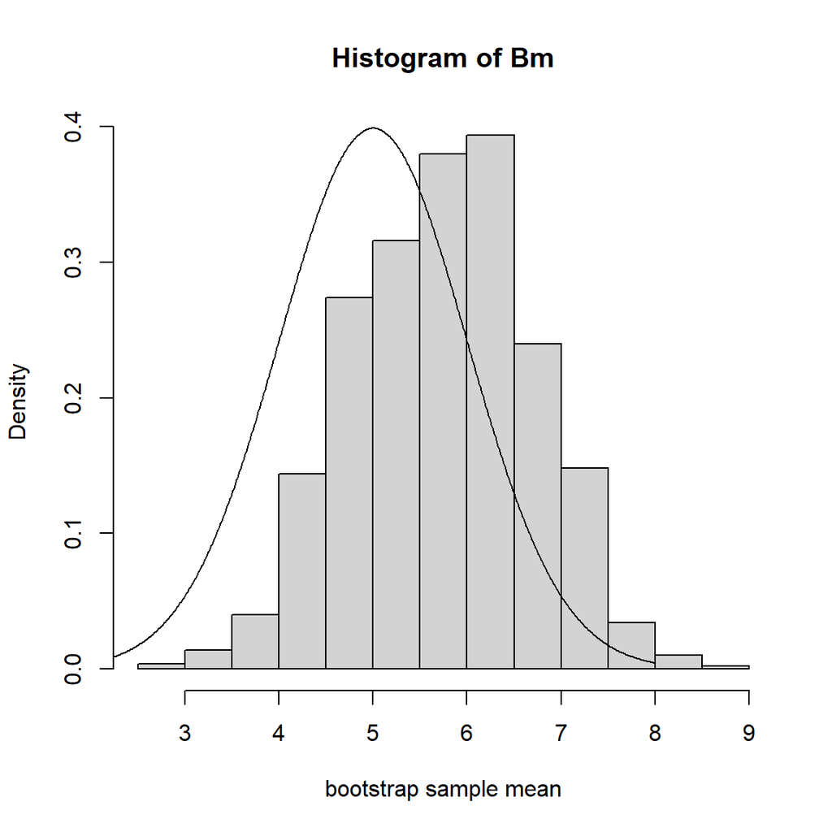

```r
B=1000
BS=matrix(0,B,length(x))
Bm=c()
for (i in 1:B)
  {
  BS[i,]=sample(x,replace=TRUE)
  Bm[i]=mean(BS[i,])
  }
hist(Bm,xlab="bootstrap sample mean", probability = T)
g = seq(5-3,5+3,0.01)
lines(g,dnorm(g,mu,sigma/sqrt(n)))
```

```r
mean(Bm)
```

```
## [1] 5.743059
```

```r
Est_var_B = var(Bm)     # estimated variance by Bootstrap
Est_var_B
```

```
## [1] 0.8962641
```

- Q : 분산에 대한 두 추정치 중 이론적인 접근은 어떤 가정에 의존한 것인가? Bootstrap 방법은 어떠한가?

하지만, 추정량이 복잡한 경우에는 분산의 형태를 정확하게 계산하는 것이 어려울 수 있다. 그리고 계산이 가능하다 하더라도 포함하고 있는 모수들이 추정이 어렵거나 효율적 추정이 어려운 경우에는 분산의 추정에도 좋지 않은 영향을 줄 수 있다. 붓스트랩은 시뮬레이션에 기초한 방법으로 추정량이 복잡한 형태이더라도 그 적용에 전혀 문제가 없다.

예를 들어 표본중앙값($m$)의 분산에 관심이 있다고 해 보자. 대표본이론에 의하면 표본의 크기가 충분히 클 때

$$var(m)\approx \frac{1}{4nf(\xi_{0.5})^2},~f:density$$

임이 알려져 있다 ($\xi_{0.5}$는 모중앙값). 하지만 위와 같은 사실을 이끌어 내는 과정이 상대적으로 복잡하고 또한 $f$를 정확하게 추정하는 것이 상대적으로 쉽지 않음이 알려져 있다.

일반적으로 어떤 모수 $\theta(F)$에 대한 추정량 $T(X)$의 분산은 다음과 같이 추정된다.

$$\hat{var}(T(X))^\ast = \frac{1}{B}\sum_{b=1}^B\left(T(X^\ast_b) - \frac{1}{B}\sum_{i=1}^BT(X^\ast_b)\right)^2$$

여기서 $T(X^\ast_b)$는 $b$번째 붓스트랩 표본으로부터 계산된 추정량이다.

> Ex : 모집단이 $N(5,10^2)$인 분포에서 크기 100인 임의표본을 추출하자. 표본중앙값의 분산은 어떻게 추정될 수 있는가?

```r
n = 100
mu = 5
sigma = 10
set.seed(23)
x = rnorm(n,mu,sigma)
Est_var = 1/(4*n*dnorm(mu,mu,sigma)^2)
Est_var     # estimated variance by a theorerical way
```

```
## [1] 1.570796
```

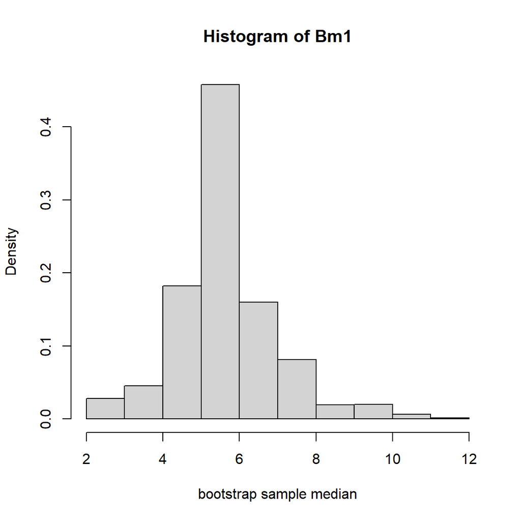

```r
B=1000
BS=matrix(0,B,length(x))
Bm1=c()
for (i in 1:B)
  {
  BS[i,]=sample(x,replace=TRUE)
  Bm1[i]=median(BS[i,])
  }
hist(Bm1,xlab="bootstrap sample median", probability = T)
```

```r
mean(Bm1)
```

```
## [1] 5.657096
```

```r
var(Bm1)     # estimated variance by Bootstrap
```

```
## [1] 1.709387
```

## 2.2 Confidence interval

붓스트랩이 가장 powerful하게 적용될 수 있는 영역이 바로 구간추정이다. 구간추정은 어떤 의미에서는 통계적 유의성과도 연결될 수 있는 개념이므로 통계적 추론에 활용될 수 있다. 특정 모수에 대한 신뢰구간을 간단히 구성하려면 추정량의 분산에 대한 정보가 필요할 수 있다. 예를 들어 모평균에 대한 신뢰구간은 (표본의 크기가 충분히 크다는 전제 혹은 모집단의 분포가 정규분포라는 전체 하에서)

$$\bar X \pm z_{\alpha/2} \sigma/\sqrt{n}$$

과 같은 형태로 주어진다. 즉, 신뢰구간을 구성하는 문제는 앞에서 언급했던 분산의 추정 문제로 귀결될 수 있다. 하지만, 이는 추정량의 (점근)분포가 정규분포일때에만 적용가능하며, 만약 그렇지 않다면 분위수에 대한 추정이 추가로 필요할 것이다. 다음은 Boottrap을 적용하여 제시할 수 있는 여러 신뢰구간에 대한 소개이다.

### 2.2.1 Normal interval

만약 추정량의 분포가 (점근적으로) 정규분포라고 할 수 있다면, 분산을 붓스트랩에 근거하여 추정하여

$$T(X) \pm z_{\alpha/2} \sqrt{\hat{var}(T(X)^\ast)}$$

와 같은 붓스트랩 신뢰구간을 구성할 수 있다.

> Ex : 모평균에 대한 붓스트랩 신뢰구간 (95%)

```r
barx = mean(x)
# by central limit theorem or normality assumption
c(barx-qnorm(0.975)*sd(x)/sqrt(n),barx+qnorm(0.975)*sd(x)/sqrt(n))
```

```
## [1] 3.906437 7.588478
```

```r
# by Bootstrap (normal interval)
c(barx-qnorm(0.975)*sqrt(Est_var_B),barx+qnorm(0.975)*sqrt(Est_var_B))
```

```
## [1] 3.891936 7.602979
```

### 2.2.2 Pivotal interval

만약 추정량의 분포가 정규분포라는 가정을 하기 어렵다면, 추정량의 표본분포에 대한 정보를 그대로 이용하여 신뢰구간을 구성하여야 한다. 신뢰구간을 구성하는 기본적인 idea를 되새겨 보자. $\theta(F)$에 대한 추정량을 $T(X)$라 하고 $T(X)-\theta(F)$의 분포함수를 $H$라 하자. 여기서 $T(X)-\theta(F)$를 피봇(pivot)이라 한다. $H$의 하위 $\alpha$ 분위수를 $u_\alpha$라 하면 다음과 같은 확률식을 쓸 수 있다.

$$P(u_{\alpha/2}\leq T(X)-\theta(F)\leq u_{1-\alpha/2})=1-\alpha.$$

핵심 idea는 $u_{\alpha/2}$, $u_{1-\alpha/2}$를 붓스트랩에 근거하여 추정하는 것이다. 즉, $B$회의 샘플링에 의해 얻어진 $B$개의 추정량의 표본분위수로 위 분위수들을 추정한다. 이를 $u_{\alpha/2}^\ast$, $u_{1-\alpha/2}^\ast$라 하면, $\theta(F)$에 대한 $100(1-\alpha)\%$ 신뢰구간은

$$(T(X)-u_{1-\alpha/2}^\ast,T(X)-u_{\alpha/2}^\ast)$$

가 된다.

단, 위 분위수들은 $T(X)$가 아니라 $T(X)-\theta(F)$의 분포의 분위수이다. $\theta(F)$는 미지의 모수이므로 실제로는 위 분위수들을 바로 얻는 것은 불가능하다. 하지만, $T(X)$의 분포의 분위수를 $v_{\alpha/2}$, $v_{1-\alpha/2}$라 하면,

$$u_{\alpha/2} = v_{\alpha/2} - \theta(F)$$

와 같은 등식이 성립한다. $v_{\alpha/2}$는 붓스트랩에 의해 추정가능하고, $\theta(F)$는 $\theta(\hat F_n)=T(X)$로 추정가능하므로

$$u_{\alpha/2}^\ast = v_{\alpha/2}^\ast - T(X)$$

를 얻을 수 있다. 따라서, 붓스트랩에 의한 신뢰구간은

$$(2T(X)-v_{1-\alpha/2}^\ast,2T(X)-v_{\alpha/2}^\ast)$$

와 같이 주어진다.

> Ex : 모평균에 대한 붓스트랩 신뢰구간 (95%)

```r
# by Bootstrap (pivotal interval)
c(2*barx-quantile(Bm,0.975),2*barx-quantile(Bm,0.025))
```

```
##    97.5%     2.5%
## 4.006992 7.574828
```

### 2.2.3 Percentile interval

Pivotal interval보다 더욱 간단한 형태로 주어지는 신뢰구간이다.

$$(v_{\alpha/2}^\ast,v_{1-\alpha/2}^\ast)$$

이 신뢰구간은 $\phi(T(X))-\phi(\theta(F))$가 0을 중심으로 대칭인 분포가 되는 적절한 변환함수 $\phi$가 존재하는 경우에만 정당화될 수 있는 것으로 알려져 있다. 즉, 편의추정량에 대해서는 좋은 신뢰구간을 제시할 수 없을 것이다.

> Ex : 모평균에 대한 붓스트랩 신뢰구간 (95%)

```r
# by Bootstrap (percentile interval)
c(quantile(Bm,0.025),quantile(Bm,0.975))
```

```
##     2.5%    97.5%
## 3.920087 7.487923
```

### 2.2.4 추정량의 분포를 정규분포로 볼 수 없는 경우

추정량의 분포가 (근사적으로) 정규분포라면 위에서 소개한 세 종류의 붓스트랩 신뢰구간은 대략 비슷한 결과를 줄 가능성이 크다. 또한, 이론적인 접근이 가능하다면 이를 이용한 신뢰구간 또한 유사한 결과를 줄 것이다.

하지만, 추정량의 분포가 정규분포가 아니라면? (언제 이런 일이 발생하겠는가?) 정규분포에 근거한 normal inverval의 신뢰성은 크게 저하될 것이다. (추정량의 형태에 따라서 조금 다를 수 있겠지만) 나머지 두 종류의 신뢰구간은 비슷한 결과를 주는 경우가 많다.

```r
n = 100
df = 2
set.seed(23)
x = rchisq(n,df)
Est_var = var(x)/n
Est_var     # estimated variance by a theorerical way
```

```
## [1] 0.04477357
```

```r
B=1000
BS=matrix(0,B,length(x))
Bm=c()
for (i in 1:B)
  {
  BS[i,]=sample(x,replace=TRUE)
  Bm[i]=mean(BS[i,])
  }
Est_var_B = var(Bm)     # estimated variance by Bootstrap
Est_var_B
```

```
## [1] 0.04454241
```

```r
barx = mean(x)
# by central limit theorem or normality assumption
c(barx-qnorm(0.975)*sd(x)/sqrt(n),barx+qnorm(0.975)*sd(x)/sqrt(n))
```

```
## [1] 1.843648 2.673095
```

```r
# by Bootstrap (normal interval)
c(barx-qnorm(0.975)*sqrt(Est_var_B),barx+qnorm(0.975)*sqrt(Est_var_B))
```

```
## [1] 1.844720 2.672023
```

```r
# by Bootstrap (pivotal interval)
c(2*barx-quantile(Bm,0.975),2*barx-quantile(Bm,0.025))
```

```
##    97.5%     2.5%
## 1.809458 2.647588
```

```r
# by Bootstrap (percentile interval)
c(quantile(Bm,0.025),quantile(Bm,0.975))
```

```
##     2.5%    97.5%
## 1.869155 2.707284
```

```r
n = 10
df = 2
set.seed(23)
x = rchisq(n,df)
Est_var = var(x)/n
Est_var     # estimated variance by a theorerical way
```

```
## [1] 0.2240771
```

```r
B=1000
BS=matrix(0,B,length(x))
Bm=c()
for (i in 1:B)
  {
  BS[i,]=sample(x,replace=TRUE)
  Bm[i]=mean(BS[i,])
  }
Est_var_B = var(Bm)     # estimated variance by Bootstrap
Est_var_B
```

```
## [1] 0.1869577
```

```r
barx = mean(x)
# by normality assumption
c(barx-qnorm(0.975)*sd(x)/sqrt(n),barx+qnorm(0.975)*sd(x)/sqrt(n))
```

```
## [1] 0.5895974 2.4451652
```

```r
# by Bootstrap (normal interval)
c(barx-qnorm(0.975)*sqrt(Est_var_B),barx+qnorm(0.975)*sqrt(Est_var_B))
```

```
## [1] 0.6699202 2.3648424
```

```r
# by Bootstrap (pivotal interval)
c(2*barx-quantile(Bm,0.975),2*barx-quantile(Bm,0.025))
```

```
##     97.5%      2.5%
## 0.6658902 2.3116039
```

```r
# by Bootstrap (percentile interval)
c(quantile(Bm,0.025),quantile(Bm,0.975))
```

```
##      2.5%     97.5%
## 0.7231587 2.3688724
```

# 3. Bootstrap in regression

## 3.1 Bootstrap sampling

회귀모형 하에서 붓스트랩 샘플을 생성하는 데에는 몇 가지 방법이 있다. 이는 design이 fixed인지 random인지에 따라서 결정할 수도 있고 모형의 가정을 고려하여 결정할 수도 있다.

### 3.1.1 Bootstrapping the residuals

- 적합된 회귀모형에 의해 생성되는 잔차를 이용하여 붓스트랩 샘플을 생성하는 접근 법으로 fixed design일때, 오차항들의 성질이 동일할 때 자연스럽게 적용할 수 있는 방법이다.
- 상대적으로 절차가 복잡하나 회귀모형의 형태를 이용한 방법으로 적절한 조건 하에서 정확하고 안정적인 결과를 기대할 수 있다.
- 오차항에 대한 특정 분포가정이 성립할 때는 모수적 붓스트랩 등을 함께 고려할 수도 있다.

자세한 절차는 본 강의에서는 다루지 않기로 한다.

### 3.1.2 Bootstrapping the pairs

회귀모형은 다음과 같이 설명변수와 반응변수의 순서쌍을 관측했다고 보통 가정하게 된다.
$$(x_1,y_1),\ldots,(x_n,y_n)$$
따라서, $n$개의 순서쌍으로부터 복원추출을 통해 크기 $n$의 표본을 재추출하면 이것을 붓스트랩 표본으로 간주할 수 있다. 이러한 과정을 $B$번 반복하여 $B$개의 붓스트랩 표본을 생성하고 이로부터 원하는 통계량의 분포를 근사할 수 있다.

- 이 방법은 모형의 형태에 의존하지 않는다.
- 오차항에 대한 가정으로부터도 상대적으로 자유롭다.
- 위와 같은 이유로 비교적 강건한(robust)한 결과를 기대할 수 있다.
- random design 하에서는 본 방식을 적용하는 것이 자연스러우나 설명변수의 값이 주어졌다고 생각하면 residual을 이용한 방식의 적용도 가능하다.

## 3.2 Bootstarp in simple linear regression models

단순선형 회귀 모형에서 계수에 대한 추론 (검정이나 신뢰구간 구성)은 모형의 가정에 크게 의존함을 배웠다. 모형의 가정이 위배될 때 붓스트랩 신뢰구간을 이용한 추론에 대해서 살펴보자.

```r
B=2000;M=1000
set.seed(1)
n=10

x=matrix(runif(n*M),M,n)
c22=1/rowSums((x-rowMeans(x))^2)
#ep=matrix(rgamma(n*M,shape=2,scale=sqrt(1/2))-sqrt(2),M,n)
ep=matrix(rcauchy(n*M),M,n)
y=2+x+ep
sxx=rowSums(x^2)-n*rowMeans(x)^2
sxy=rowSums(x*y)-n*rowMeans(x)*rowMeans(y)
hb=cbind(rowMeans(y)-(sxy/sxx)*rowMeans(x),sxy/sxx)
e=y-hb[,1]-x*hb[,2]
hsigma=sqrt(rowSums(e^2)/(n-2))
c22=1/rowSums((x-rowMeans(x))^2)
Bm0=Bm1=matrix(0,M,B)


for (i in 1:B)
  {
  hi=sample(1:n,replace=T)
  hx=x[,hi]
  hy=y[,hi]
  sxxb=rowSums(hx*hx)-n*rowMeans(hx)*rowMeans(hx)
  sxyb=rowSums(hx*hy)-n*rowMeans(hx)*rowMeans(hy)
  hbb=cbind(rowMeans(hy)-(sxyb/sxxb)*rowMeans(hx),sxyb/sxxb)
  Bm0[,i]=hbb[,1]
  Bm1[,i]=hbb[,2]
}
# Bootstrap C.I. (normal interval)
BN=cbind(hb[,2]-qnorm(0.975)*apply(Bm1,1,sd),hb[,2]+qnorm(0.975)*apply(Bm1,1,sd))
# Bootstrap C.I. (Pivotal interval)
BP=cbind(2*hb[,2]-apply(Bm1,1,quantile,probs=0.975),2*hb[,2]-qnorm(0.975)*apply(Bm1,1,quantile,probs=0.025))
# Bootstrap C.I. (Percentile interval)
BPer=cbind(apply(Bm1,1,quantile,probs=0.025),apply(Bm1,1,quantile,probs=0.975))
# theoretical C.I. (normal interval)
AN=cbind(hb[,2]-qnorm(0.975)*sqrt(hsigma^2/sxx),hb[,2]+qnorm(0.975)*sqrt(hsigma^2/sxx))  # average lengths of intervals
c(diff(colMeans(BN)),diff(colMeans(BP)),diff(colMeans(BPer)),diff(colMeans(AN)))
```

```
## [1]  85.08582 116.87005  73.96018  86.89778
```

```r
# coverage proportions
c(mean(apply(BN-1,1,prod)<0),mean(apply(BP-1,1,prod)<0),mean(apply(BPer-1,1,prod)<0),mean(apply(AN-1,1,prod)<0))
```

```
## [1] 0.966 0.973 0.913 0.928
```

> Ex : 정규성 가정의 위배 (소표본)
- $y_i = 2 + x_i + \epsilon_i$
- $X_i \sim^{iid} U(0,1)$
- $\epsilon_i \sim^{iid} \Gamma(2,\sqrt{1/2})$
- 붓스트랩 샘플수 2000, 95% 신뢰구간 구성 1000번 반복
- 1000개의 신뢰구간 중 실제 모수를 포함하는 비율 계산

```r
B=2000;M=1000
set.seed(1)
n=10

x=matrix(runif(n*M),M,n)
c22=1/rowSums((x-rowMeans(x))^2)
ep=matrix(rgamma(n*M,shape=2,scale=sqrt(1/2))-sqrt(2),M,n)
#ep=matrix(rnorm(n*M),M,n)
y=2+x+ep
sxx=rowSums(x^2)-n*rowMeans(x)^2
sxy=rowSums(x*y)-n*rowMeans(x)*rowMeans(y)
hb=cbind(rowMeans(y)-(sxy/sxx)*rowMeans(x),sxy/sxx)
e=y-hb[,1]-x*hb[,2]
hsigma=sqrt(rowSums(e^2)/(n-2))
c22=1/rowSums((x-rowMeans(x))^2)
Bm0=Bm1=matrix(0,M,B)


for (i in 1:B)
  {
  hi=sample(1:n,replace=T)
  hx=x[,hi]
  hy=y[,hi]
  sxxb=rowSums(hx*hx)-n*rowMeans(hx)*rowMeans(hx)
  sxyb=rowSums(hx*hy)-n*rowMeans(hx)*rowMeans(hy)
  hbb=cbind(rowMeans(hy)-(sxyb/sxxb)*rowMeans(hx),sxyb/sxxb)
  Bm0[,i]=hbb[,1]
  Bm1[,i]=hbb[,2]
}
# Bootstrap C.I. (normal interval)
BN=cbind(hb[,2]-qnorm(0.975)*apply(Bm1,1,sd),hb[,2]+qnorm(0.975)*apply(Bm1,1,sd))
# Bootstrap C.I. (Pivotal interval)
BP=cbind(2*hb[,2]-apply(Bm1,1,quantile,probs=0.975),2*hb[,2]-qnorm(0.975)*apply(Bm1,1,quantile,probs=0.025))
# Bootstrap C.I. (Percentile interval)
BPer=cbind(apply(Bm1,1,quantile,probs=0.025),apply(Bm1,1,quantile,probs=0.975))
# theoretical C.I. (normal interval)
AN=cbind(hb[,2]-qnorm(0.975)*sqrt(hsigma^2/sxx),hb[,2]+qnorm(0.975)*sqrt(hsigma^2/sxx))  # average lengths of intervals
c(diff(colMeans(BN)),diff(colMeans(BP)),diff(colMeans(BPer)),diff(colMeans(AN)))
```

```
## [1] 5.116709 6.362796 4.928345 4.515607
```

```r
# coverage proportions
c(mean(apply(BN-1,1,prod)<0),mean(apply(BP-1,1,prod)<0),mean(apply(BPer-1,1,prod)<0),mean(apply(AN-1,1,prod)<0))
```

```
## [1] 0.932 0.947 0.904 0.907
```

> Ex : 정규성 가정의 위배 (대표본)
- $y_i = 2 + x_i + \epsilon_i$
- $X_i \sim^{iid} U(0,1)$
- $\epsilon_i \sim^{iid} \Gamma(2,\sqrt{1/2})$
- 붓스트랩 샘플수 2000, 95% 신뢰구간 구성 1000번 반복
- 1000개의 신뢰구간 중 실제 모수를 포함하는 비율 계산

```r
B=2000;M=1000
set.seed(1)
n=50

x=matrix(runif(n*M),M,n)
c22=1/rowSums((x-rowMeans(x))^2)
ep=matrix(rgamma(n*M,shape=2,scale=sqrt(1/2))-sqrt(2),M,n)
#ep=matrix(rnorm(n*M),M,n)
y=2+x+ep
sxx=rowSums(x^2)-n*rowMeans(x)^2
sxy=rowSums(x*y)-n*rowMeans(x)*rowMeans(y)
hb=cbind(rowMeans(y)-(sxy/sxx)*rowMeans(x),sxy/sxx)
e=y-hb[,1]-x*hb[,2]
hsigma=sqrt(rowSums(e^2)/(n-2))
c22=1/rowSums((x-rowMeans(x))^2)
Bm0=Bm1=matrix(0,M,B)


for (i in 1:B)
  {
  hi=sample(1:n,replace=T)
  hx=x[,hi]
  hy=y[,hi]
  sxxb=rowSums(hx*hx)-n*rowMeans(hx)*rowMeans(hx)
  sxyb=rowSums(hx*hy)-n*rowMeans(hx)*rowMeans(hy)
  hbb=cbind(rowMeans(hy)-(sxyb/sxxb)*rowMeans(hx),sxyb/sxxb)
  Bm0[,i]=hbb[,1]
  Bm1[,i]=hbb[,2]
}
# Bootstrap C.I. (normal interval)
BN=cbind(hb[,2]-qnorm(0.975)*apply(Bm1,1,sd),hb[,2]+qnorm(0.975)*apply(Bm1,1,sd))
# Bootstrap C.I. (Pivotal interval)
BP=cbind(2*hb[,2]-apply(Bm1,1,quantile,probs=0.975),2*hb[,2]-qnorm(0.975)*apply(Bm1,1,quantile,probs=0.025))
# Bootstrap C.I. (Percentile interval)
BPer=cbind(apply(Bm1,1,quantile,probs=0.025),apply(Bm1,1,quantile,probs=0.975))
# theoretical C.I. (normal interval)
AN=cbind(hb[,2]-qnorm(0.975)*sqrt(hsigma^2/sxx),hb[,2]+qnorm(0.975)*sqrt(hsigma^2/sxx))  # average lengths of intervals
c(diff(colMeans(BN)),diff(colMeans(BP)),diff(colMeans(BPer)),diff(colMeans(AN)))
```

```
## [1] 1.908465 1.878544 1.906769 1.932041
```

```r
# coverage proportions
c(mean(apply(BN-1,1,prod)<0),mean(apply(BP-1,1,prod)<0),mean(apply(BPer-1,1,prod)<0),mean(apply(AN-1,1,prod)<0))
```

```
## [1] 0.952 0.982 0.949 0.953
```

```r
B=2000;M=1000
set.seed(1)
n=10

x=matrix(runif(n*M),M,n)
c22=1/rowSums((x-rowMeans(x))^2)
ep=matrix(rgamma(n*M,shape=2,scale=sqrt(1/2))-sqrt(2),M,n)
#ep=matrix(rnorm(n*M),M,n)
y=2+x+ep*abs(x-10)
sxx=rowSums(x^2)-n*rowMeans(x)^2
sxy=rowSums(x*y)-n*rowMeans(x)*rowMeans(y)
hb=cbind(rowMeans(y)-(sxy/sxx)*rowMeans(x),sxy/sxx)
e=y-hb[,1]-x*hb[,2]
hsigma=sqrt(rowSums(e^2)/(n-2))
c22=1/rowSums((x-rowMeans(x))^2)
Bm0=Bm1=matrix(0,M,B)


for (i in 1:B)
  {
  hi=sample(1:n,replace=T)
  hx=x[,hi]
  hy=y[,hi]
  sxxb=rowSums(hx*hx)-n*rowMeans(hx)*rowMeans(hx)
  sxyb=rowSums(hx*hy)-n*rowMeans(hx)*rowMeans(hy)
  hbb=cbind(rowMeans(hy)-(sxyb/sxxb)*rowMeans(hx),sxyb/sxxb)
  Bm0[,i]=hbb[,1]
  Bm1[,i]=hbb[,2]
}
# Bootstrap C.I. (normal interval)
BN=cbind(hb[,2]-qnorm(0.975)*apply(Bm1,1,sd),hb[,2]+qnorm(0.975)*apply(Bm1,1,sd))
# Bootstrap C.I. (Pivotal interval)
BP=cbind(2*hb[,2]-apply(Bm1,1,quantile,probs=0.975),2*hb[,2]-qnorm(0.975)*apply(Bm1,1,quantile,probs=0.025))
# Bootstrap C.I. (Percentile interval)
BPer=cbind(apply(Bm1,1,quantile,probs=0.025),apply(Bm1,1,quantile,probs=0.975))
# theoretical C.I. (normal interval)
AN=cbind(hb[,2]-qnorm(0.975)*sqrt(hsigma^2/sxx),hb[,2]+qnorm(0.975)*sqrt(hsigma^2/sxx))  # average lengths of intervals
c(diff(colMeans(BN)),diff(colMeans(BP)),diff(colMeans(BPer)),diff(colMeans(AN)))
```

```
## [1] 48.62961 68.74807 46.84358 42.92363
```

```r
# coverage proportions
c(mean(apply(BN-1,1,prod)<0),mean(apply(BP-1,1,prod)<0),mean(apply(BPer-1,1,prod)<0),mean(apply(AN-1,1,prod)<0))
```

```
## [1] 0.934 0.946 0.902 0.908
```

```r
B=2000;M=1000
set.seed(1)
n=10

x=matrix(runif(n*M),M,n)
c22=1/rowSums((x-rowMeans(x))^2)
ep = matrix(arima.sim(model = list(ar = 0.8), n = M*n),M,n)
y=2+x+ep
sxx=rowSums(x^2)-n*rowMeans(x)^2
sxy=rowSums(x*y)-n*rowMeans(x)*rowMeans(y)
hb=cbind(rowMeans(y)-(sxy/sxx)*rowMeans(x),sxy/sxx)
e=y-hb[,1]-x*hb[,2]
hsigma=sqrt(rowSums(e^2)/(n-2))
c22=1/rowSums((x-rowMeans(x))^2)
Bm0=Bm1=matrix(0,M,B)


for (i in 1:B)
  {
  hi=sample(1:n,replace=T)
  hx=x[,hi]
  hy=y[,hi]
  sxxb=rowSums(hx*hx)-n*rowMeans(hx)*rowMeans(hx)
  sxyb=rowSums(hx*hy)-n*rowMeans(hx)*rowMeans(hy)
  hbb=cbind(rowMeans(hy)-(sxyb/sxxb)*rowMeans(hx),sxyb/sxxb)
  Bm0[,i]=hbb[,1]
  Bm1[,i]=hbb[,2]
}
# Bootstrap C.I. (normal interval)
BN=cbind(hb[,2]-qnorm(0.975)*apply(Bm1,1,sd),hb[,2]+qnorm(0.975)*apply(Bm1,1,sd))
# Bootstrap C.I. (Pivotal interval)
BP=cbind(2*hb[,2]-apply(Bm1,1,quantile,probs=0.975),2*hb[,2]-qnorm(0.975)*apply(Bm1,1,quantile,probs=0.025))
# Bootstrap C.I. (Percentile interval)
BPer=cbind(apply(Bm1,1,quantile,probs=0.025),apply(Bm1,1,quantile,probs=0.975))
# theoretical C.I. (normal interval)
AN=cbind(hb[,2]-qnorm(0.975)*sqrt(hsigma^2/sxx),hb[,2]+qnorm(0.975)*sqrt(hsigma^2/sxx))  # average lengths of intervals
c(diff(colMeans(BN)),diff(colMeans(BP)),diff(colMeans(BPer)),diff(colMeans(AN)))
```

```
## [1]  8.501556 11.133699  8.132749  7.451194
```

```r
# coverage proportions
c(mean(apply(BN-1,1,prod)<0),mean(apply(BP-1,1,prod)<0),mean(apply(BPer-1,1,prod)<0),mean(apply(AN-1,1,prod)<0))
```

```
## [1] 0.934 0.960 0.927 0.927
```

# 4. Exercise

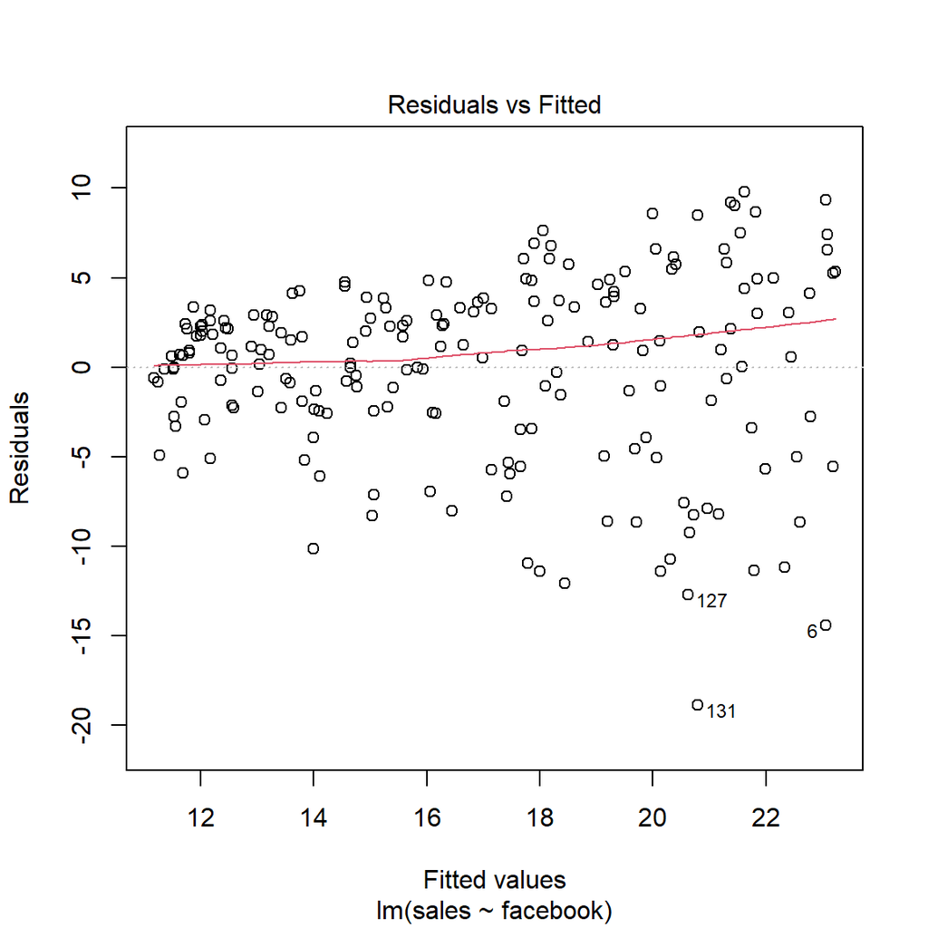

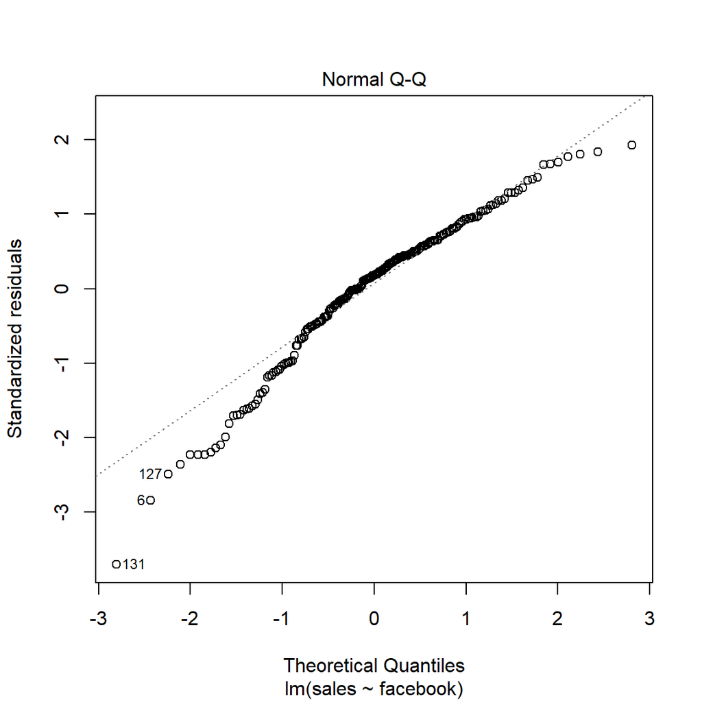

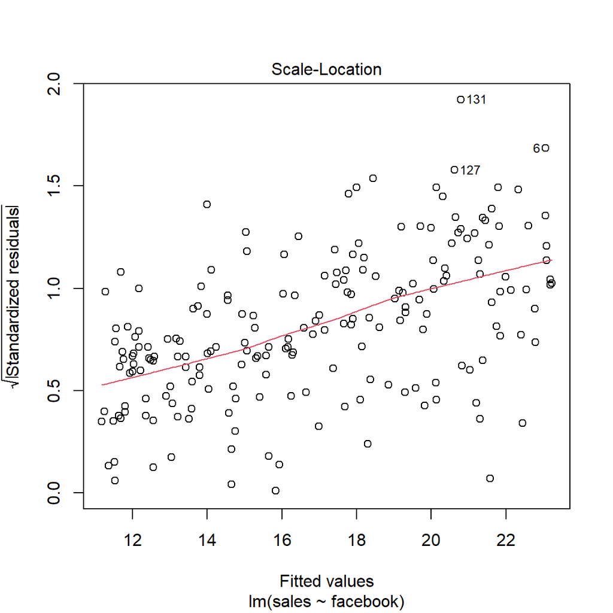

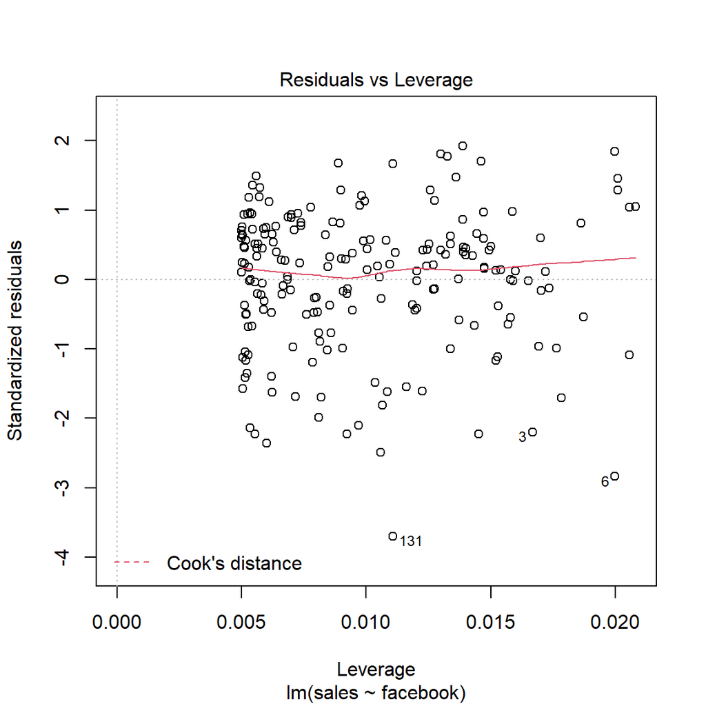

```r
data("marketing", package = "datarium")
fit <- lm(sales ~ facebook, data = marketing)
plot(fit)
```

```r
library(gvlma)
summary(gvlma(x=fit))
```

```
##
## Call:
## lm(formula = sales ~ facebook, data = marketing)
##
## Residuals:
##      Min       1Q   Median       3Q      Max
## -18.8766  -2.5589   0.9248   3.3330   9.8173
##
## Coefficients:
##             Estimate Std. Error t value Pr(>|t|)
## (Intercept) 11.17397    0.67548  16.542   <2e-16 ***
## facebook     0.20250    0.02041   9.921   <2e-16 ***
## ---
## Signif. codes:  0 '***' 0.001 '**' 0.01 '*' 0.05 '.' 0.1 ' ' 1
##
## Residual standard error: 5.13 on 198 degrees of freedom
## Multiple R-squared:  0.332,  Adjusted R-squared:  0.3287
## F-statistic: 98.42 on 1 and 198 DF,  p-value: < 2.2e-16
##
##
## ASSESSMENT OF THE LINEAR MODEL ASSUMPTIONS
## USING THE GLOBAL TEST ON 4 DEGREES-OF-FREEDOM:
## Level of Significance =  0.05
##
## Call:
##  gvlma(x = fit)
##
##                       Value   p-value                   Decision
## Global Stat        22.06943 1.941e-04 Assumptions NOT satisfied!
## Skewness           19.44101 1.038e-05 Assumptions NOT satisfied!
## Kurtosis            2.46868 1.161e-01    Assumptions acceptable.
## Link Function       0.09453 7.585e-01    Assumptions acceptable.
## Heteroscedasticity  0.06520 7.985e-01    Assumptions acceptable.
```

```r
shapiro.test(fit$residuals)
```

```
##
##  Shapiro-Wilk normality test
##
## data:  fit$residuals
## W = 0.96072, p-value = 2.367e-05
```

```r
library(car)
ncvTest(fit)
```

```
## Non-constant Variance Score Test
## Variance formula: ~ fitted.values
## Chisquare = 46.61861, Df = 1, p = 8.6237e-12
```

```r
B=2000
set.seed(1)
n = length(marketing$sales)
Bm1=c()

for (i in 1:B)
  {
  hi=sample(1:n,replace=T)
  hx=marketing$facebook[hi]
  hy=marketing$sales[hi]
  Bm1[i]=lm(hy~hx)$coefficients[2]
}

hb=fit$coefficients[2]

# Bootstrap C.I. (normal interval)
c(hb-qnorm(0.975)*sd(Bm1),hb+qnorm(0.975)*sd(Bm1))
```

```
##  facebook  facebook
## 0.1601905 0.2448011
```

```r
# Bootstrap C.I. (Pivotal interval)
c(2*hb-quantile(Bm1,probs=0.975),2*hb-quantile(Bm1,probs=0.025))
```

```
##  facebook  facebook
## 0.1615734 0.2469393
```

```r
# Bootstrap C.I. (Percentile interval)
c(quantile(Bm1,probs=0.025),quantile(Bm1,probs=0.975))
```

```
##      2.5%     97.5%
## 0.1580523 0.2434182
```

```r
# CI by theory
confint(fit)
```

```
##                 2.5 %     97.5 %
## (Intercept) 9.8419062 12.5060253
## facebook    0.1622443  0.2427472
```